# Reproducible Report Template

Project 1

Eden Zhang

# 1 Executive Summary

# 2 Full Report

## 2.1 Initial Data Analysis (IDA)

### 2.1.1 Source

- This data was collected by the International Air Transport Association (IATA) and the source was from The Bureau of Transportation Statistics (BTS). Since BTS is a government organisation in the United States, the source of our data is considered reputable. The data covers flight information of the airports in the United States only and it includes the arrival/departure delays and flight cancellation and covers the flight information of the whole year of 2008.

The data set has nearly 2 million entries and no analysis has been done on the data as it is a primary resource. This allows us to reduce the sampling error and other additional changes made by 3rd parties. Unfortunately, the source did not indicate how the data was collected and there was some missing data which may affect the reliability.

- The data set’s potential limitation is its non-random sampling, covering only the United States, leading to potential selection bias therefore, it may not provide an accurate representation of flight information for other countries. It also only includes data from 2008, restricting the study’s scope. Furthermore, since it’s based on older data, it may not accurately reflect current flight delays due to technological advancements and changes over time.
- Potential stakeholders include

**Airlines:** Airlines can use this information to rearrange their schedules to avoid the possibilities of delaying their flights for their passengers

**Passengers:** Passengers will find this information useful when planning e.g which airline they choose for their flights, what days to avoid flying etc

**Air Traffic Control:** Air Traffic control can use this to minimise air traffic congestion and reduce delays

**Airport vendors and service providers:** Airport vendors and service providers utilise these delays to provide their services while passengers wait.

### 2.1.2 Variables

Our dataset is very large and consists of 30 variables, however, for our two research questions, we will be mainly focussing on the variables **‘ArrDelay’, ‘DepDelay’ and ‘Origin’.**

**‘ArrDelay’** conveys the delay in IATA’s plane arrivals in minutes. This is the difference between the planes’ originally planned time to arrive and its actual arrival time. Negative numbers means the plane had arrived earlier than the scheduled time.

**‘DepDelay’** demonstrates the delay in IATA’s plane departures in minutes. Likewise, this is the difference between the planes’ originally planned time to depart and its actual departure time. Any negative numbers indicate the plane had departed earlier than the scheduled time.

**‘Origin’** denotes the origin airport IATA code and in other words, the starting point of the journey where the aeroplane departed. The IATA code is the alphabetic and unique identifier for airports; it consists of 3 letters for each airport and recognised by airlines and travel agencies, internationally

```r
## read in data
data <- read.csv("data/DelayedFlights.csv",header=T)
data <- na.omit(data)


## show classification of variables
UA_data <- subset(data, UniqueCarrier == "UA")
UA_ArrDelay <- UA_data$ArrDelay
UA_DepDelay <- UA_data$DepDelay

DL_data <- subset(data, UniqueCarrier == "DL")
DL_DepDelay <- DL_data$DepDelay

AA_data <- subset(data, UniqueCarrier == "AA")
AA_DepDelay <- AA_data$DepDelay

WN_data <- subset(data, UniqueCarrier == "WN")
WN_DepDelay <- WN_data$DepDelay
```

## 2.2 Research Question 1: In 2008, is there correlation between the departure times and delay times for United Airlines.

**Definitions:** By plotting the Arrival Delays against the Departure Delays of all United Airlines (UA) flight in 2008, there is a positive linear relationship between the two variables.

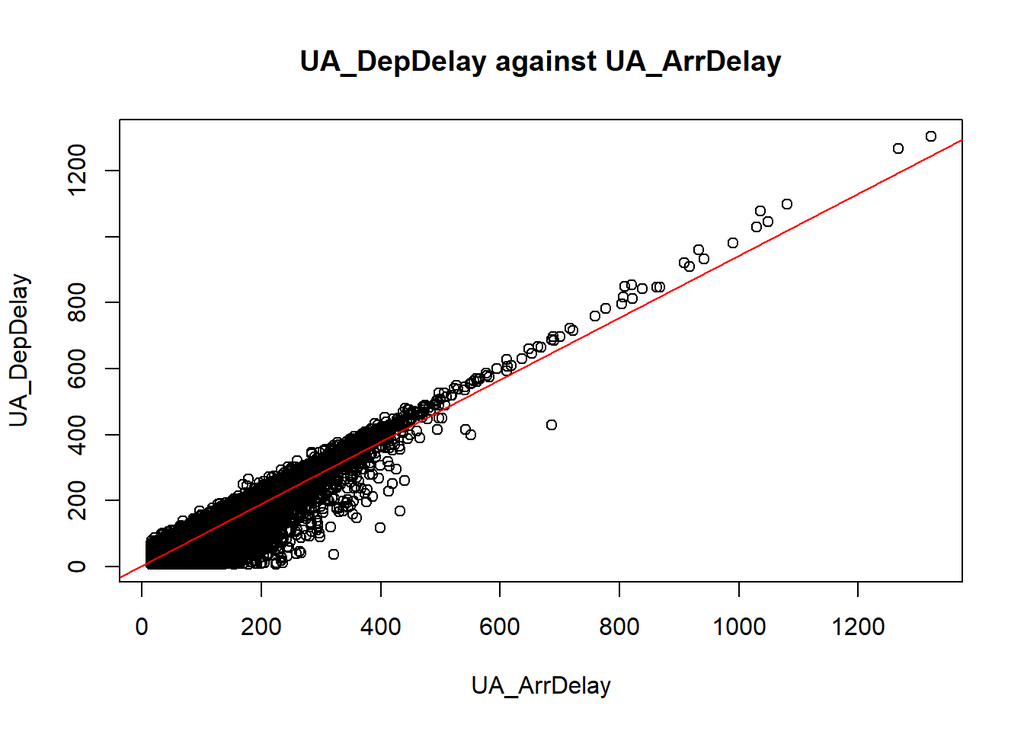

```r
plot(UA_ArrDelay, UA_DepDelay, main = "UA_DepDelay against UA_ArrDelay")
l = lm(UA_DepDelay ~ UA_ArrDelay)
abline(l, col = 'red')
```

```r
l
```

```
##
## Call:
## lm(formula = UA_DepDelay ~ UA_ArrDelay)
##
## Coefficients:
## (Intercept)  UA_ArrDelay
##      1.8807       0.9403
```

By fitting a linear regression between two variables we can generalise an equation predicting for predicting UA Departure Delay delays from UA Arrival Delay times. UA_DepDelay = m * UA_ArrDelay + c hat(UA_DepDelay) = 0.9403 * UA_ArrDelay + 1.8807

This statement will hold true when departure delay is less than or equal to zero. In other words if UA arrives earlier than 2 minutes, the prediction will not be true and we know that flights do not depart earlier than its set time.

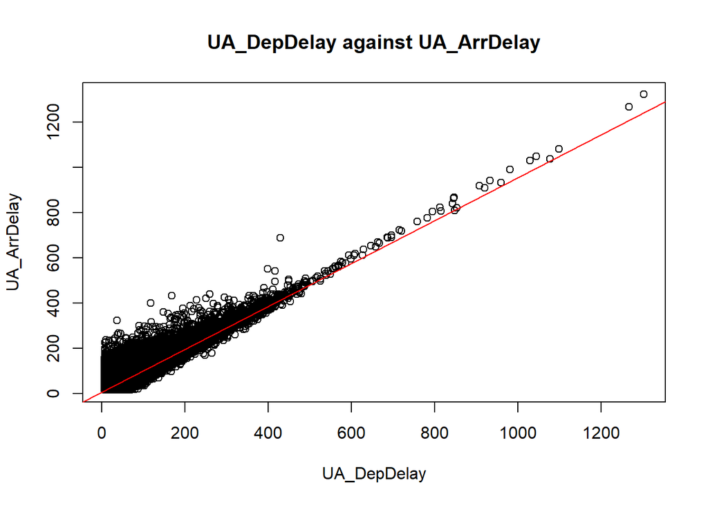

```r
plot(UA_DepDelay, UA_ArrDelay, main = "UA_DepDelay against UA_ArrDelay")
l = lm(UA_ArrDelay ~ UA_DepDelay)
abline(l, col = 'red')
```

```r
l
```

```
##
## Call:
## lm(formula = UA_ArrDelay ~ UA_DepDelay)
##
## Coefficients:
## (Intercept)  UA_DepDelay
##      5.7428       0.9484
```

Inversely, we can also predict UA Arrival Delay delays from UA Departure Delay times.

UA_ArrDelay = m * UA_DepDelay + c hat(UA_ArrDelay) = 0.9484 * UA_DepDelay + 5.7428

```r
cor(UA_ArrDelay, UA_DepDelay)
```

```
## [1] 0.944296
```

Furthermore, the correlation coefficient between the two variables is 0.944296. This means that 94% of the data are tightly closed around the line of best fit which suggests that there is a strong relationship between arrival delay times and departure delay times for UA.

To understand why the correlation is not as a tighter fit than the current fit, we can check the extreme values of United Airline departure delay times and arrival delay times. This is because the correlation coefficient is greatly impacted by extreme values.

To measure the spread of the data and check if there are any extreme values, we use can use a boxplot and plot the data. To calculate if a data point is an extreme value or outline it must be between Q1 - 1.5IQR < UA_ArrDelay or UA_DepDelay < Q3 + 1.5IQR where Q1 is the first quartile, Q3 is the 3rd quartile and IQR is the interquartile range.

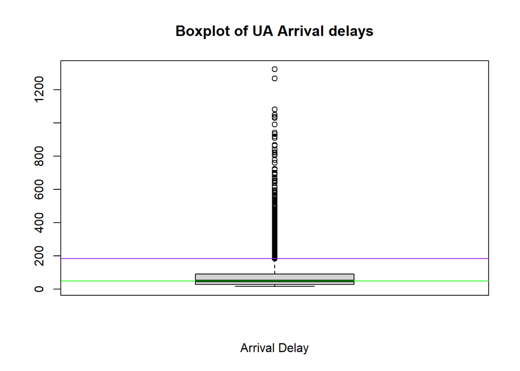

```r
boxplot(UA_ArrDelay, main="Boxplot of UA Arrival delays", xlab="Arrival Delay")
iqr=quantile(UA_ArrDelay)[4] - quantile(UA_ArrDelay)[2]
abline(h=median(UA_ArrDelay), col = "green")
abline(h=quantile(UA_ArrDelay)[2] - 1.5 * iqr, col = "purple")
abline(h=quantile(UA_ArrDelay)[4] + 1.5 * iqr, col = "purple")
```

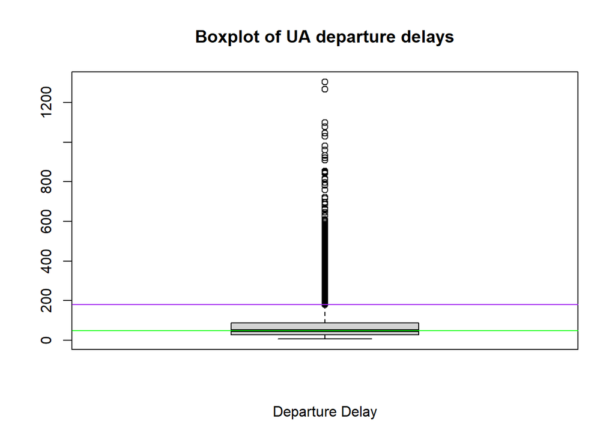

```r
boxplot(UA_DepDelay, main="Boxplot of UA departure delays", xlab="Departure Delay")
iqr=quantile(UA_DepDelay)[4] - quantile(UA_DepDelay)[2]
abline(h=median(UA_DepDelay), col = "green")
abline(h=quantile(UA_DepDelay)[2] - 1.5 * iqr, col = "purple")
abline(h=quantile(UA_DepDelay)[4] + 1.5 * iqr, col = "purple")
```

```r
Outlier_UA_ArrDelay = sum(UA_ArrDelay < (quantile(UA_ArrDelay)[2] - 1.5 * iqr)) + sum(UA_ArrDelay > (quantile(UA_ArrDelay)[4] + 1.5 * iqr))

Outlier_IQR_UA_DepDelay = sum(UA_DepDelay < (quantile(UA_DepDelay)[2] - 1.5 * iqr)) + sum(UA_DepDelay > (quantile(UA_DepDelay)[4] + 1.5 * iqr))

cat("Number of outliers for UA arrival delays: ", Outlier_UA_ArrDelay)
```

```
## Number of outliers for UA arrival delays:  5361
```

```r
cat("Number of outliers for UA departure delays: ", Outlier_IQR_UA_DepDelay)
```

```
## Number of outliers for UA departure delays:  5236
```

```r
cat("Proportion of outliers for UA arrival delays: ", (Outlier_UA_ArrDelay / length(UA_ArrDelay)) * 100)
```

```
## Proportion of outliers for UA arrival delays:  5.615671
```

```r
cat("Proportion of outliers for UA depature delays: ",(Outlier_IQR_UA_DepDelay / length(UA_DepDelay)) * 100)
```

```
## Proportion of outliers for UA depature delays:  5.484733
```

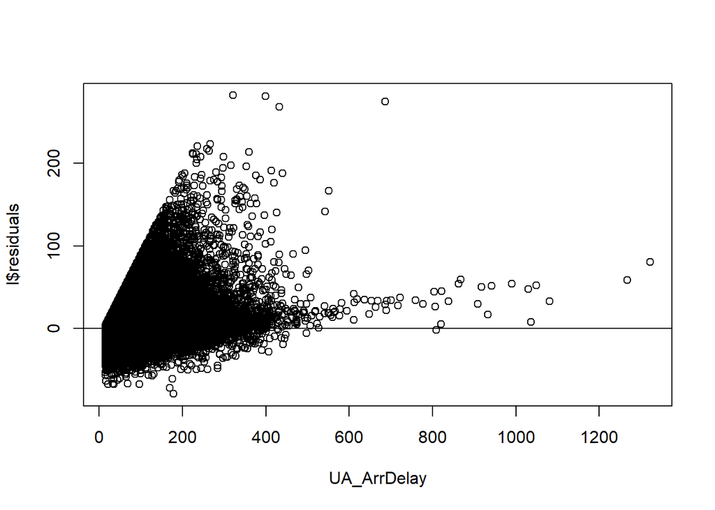

```r
plot(UA_ArrDelay, l$residuals)
abline(h=0)
```

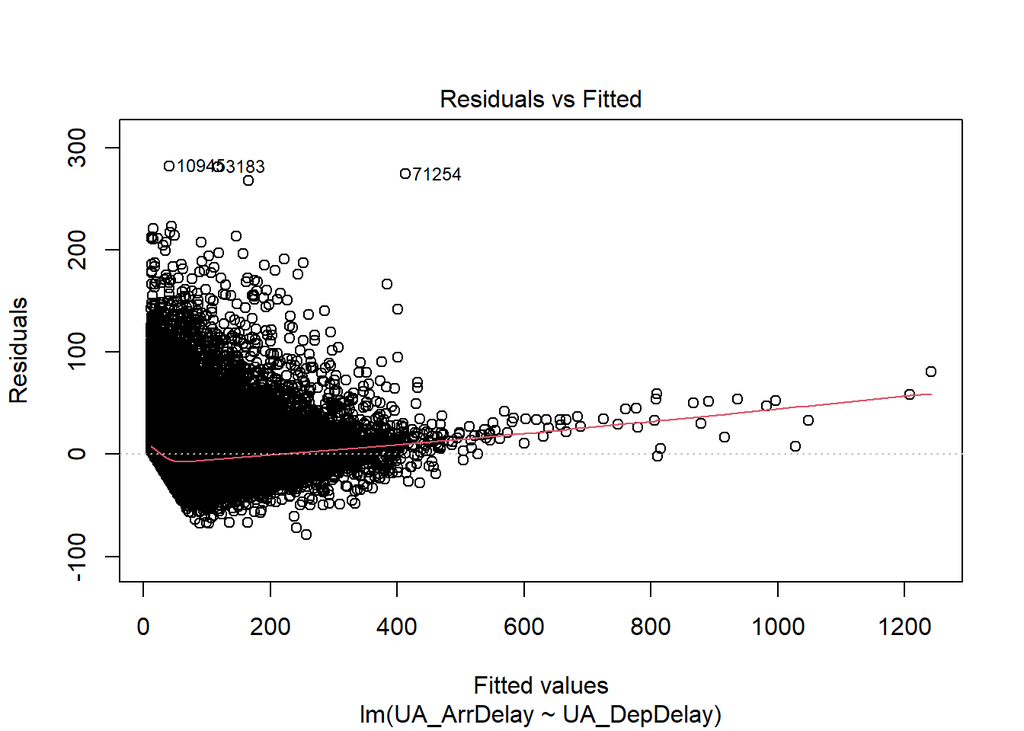

```r
plot(l, which = 1)
```

Therefore since it is heteroscedastic, the linear model cannot be used for predictions. This is because the prediction drawn from the research will have a great change in the variances and therefore the prediction will be weak as the difference between the predicted and the actual results are large.

## 2.3 Research Question 2: Which airline should I choose if I am flying out of Los Angeles International Airport (in 2008) ?

**Definitions:** To answer this question, we will simplify the amount of airlines down to the 4 biggest airlines. UA(United Airlines), DL(Delta Airlines), AA(American Airlines), and WN(Southwest Airlines). Furthermore, we have to investigate the probability of an aircraft delayed. However, the delays of an aircraft departure can vary greatly so we define the maximum acceptable time for an aircraft to be delayed as 15 minutes from the set departure time. This is because delays happen due to the boarding of an airplane, the time it takes to taxi on the runway and other reasons listed in the IDA.

```r
acceptable_delay = 15
```

In this example, it uses the United Airline Departure Delay times. By performing a logarithmic transformation on this data it turns a data that is positively skewed into a more ‘normal’ distribution. However, a limitation with this is that if there are negative numbers in the data, it will result in the loss of data points and decrease the accuracy of the probability calculated from the population data. This is because log(negative number) does not exist and will omit the data by turning it into NA.

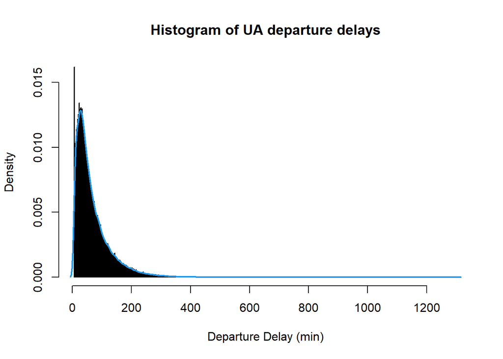

```r
## write code here

UA_ArrDelay <- UA_data$ArrDelay
UA_DepDelay <- UA_data$DepDelay

if(sum(UA_ArrDelay < 1) == 0){
  log_UA_DepDelay <- log(UA_DepDelay)
}

# positively skewed
hist(UA_DepDelay, pr = T, breaks = "fd", main="Histogram of UA departure delays", xlab="Departure Delay (min)",freq=F)
lines(density(UA_DepDelay), col = 4, lwd = 2)
```

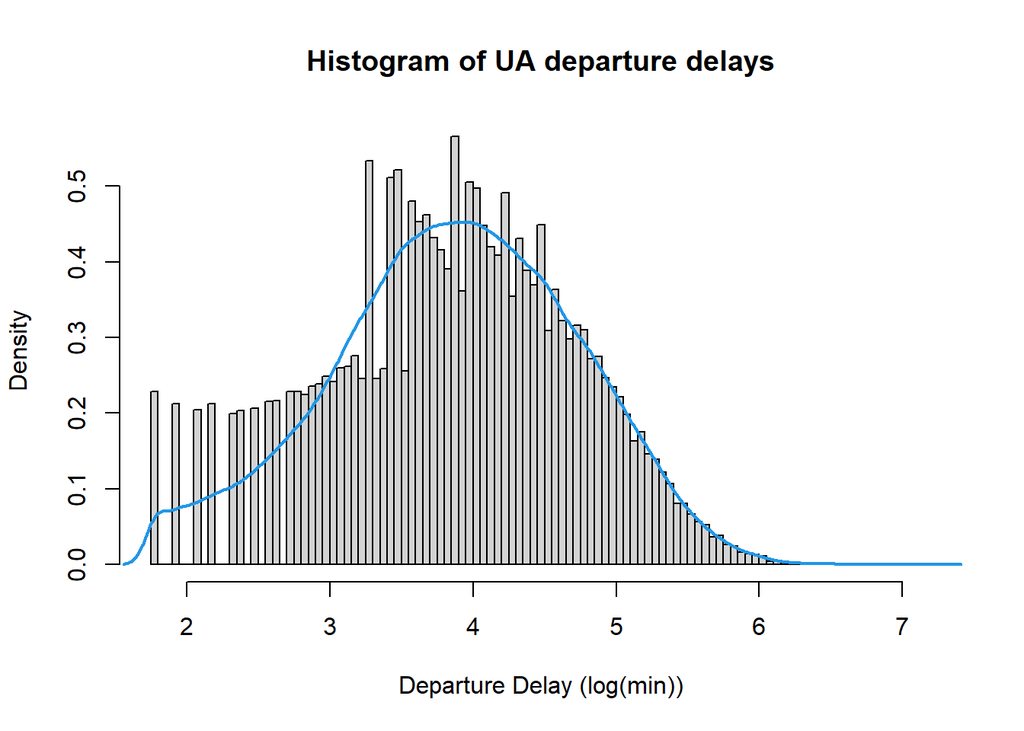

```r
# log transformation for normalizing skewed distribution
hist(log_UA_DepDelay, pr = T, breaks = "fd", main="Histogram of UA departure delays", xlab="Departure Delay (log(min))",freq=F)
lines(density(log_UA_DepDelay), col = 4, lwd = 2)
```

Since we have taken the logarithm of UA_DepDelay then it makes sense to take the logarithm of acceptable time.

Furthermore, to answer the research question, we know that the flight will come from Los Angeles International Airport so therefore we would use conditional probability. The formula for conditional probability is P(event1 | event2) is the P(event1) * P(event2) given that each event is independent given that these two events are independent.

```r
prob_15min_delay_UA = pnorm(log(acceptable_delay), mean(log_UA_DepDelay), sd(log_UA_DepDelay))
prob_origin_LAX_UA = sum(UA_data$Origin == "LAX") / length(UA_data$Origin)
prob_UA = prob_15min_delay_UA * prob_origin_LAX_UA
```

Hence we would repeat the same steps to calculate the probability for the other 3 airlines.

```r
if(sum(DL_DepDelay < 1) == 0){
    log_DL_DepDelay = log(DL_DepDelay)
}

prob_15min_delay_DL = pnorm(log(acceptable_delay), mean(log_DL_DepDelay), sd(log_DL_DepDelay))
prob_origin_LAX_DL = sum(DL_data$Origin == "LAX") / length(DL_data$Origin)
prob_DL = prob_15min_delay_DL * prob_origin_LAX_DL

if(sum(AA_DepDelay < 1) == 0){
    log_AA_DepDelay = log(AA_DepDelay)
}

prob_15min_delay_AA = pnorm(log(acceptable_delay), mean(log_AA_DepDelay), sd(log_AA_DepDelay))
prob_origin_LAX_AA = sum(AA_data$Origin == "LAX") / length(AA_data$Origin)
prob_AA = prob_15min_delay_AA * prob_origin_LAX_AA

if(sum(WN_DepDelay < 1) == 0){
    log_WN_DepDelay = log(WN_DepDelay)
}

prob_15min_delay_WN = pnorm(log(acceptable_delay), mean(log_WN_DepDelay), sd(log_WN_DepDelay))
prob_origin_LAX_WN = sum(WN_data$Origin == "LAX") / length(WN_data$Origin)
prob_WN = prob_15min_delay_WN * prob_origin_LAX_WN
```

Comparing the probability between the 4 chosen airlines

```r
cat("Probability United Airlines: ", prob_UA)
```

```
## Probability United Airlines:  0.004894065
```

```r
cat("Probability Delta Airlines: ", prob_DL)
```

```
## Probability Delta Airlines:  0.003758084
```

```r
cat("Probability American Airlines: ", prob_AA)
```

```
## Probability American Airlines:  0.004787575
```

```r
cat("Probability Western Airlines: ", prob_WN)
```

```
## Probability Western Airlines:  0.003616482
```

However we must note the limitations in this study is that we assumed that the probability of events are independent. However, this is not the case as the probability of delayed flights is dependent on many other factors listed in our IDA.

## 2.4 Additional Research.

**Queston 1:**A strong relationship between plane departure delays and arrival delays was implied that as the departure delays increases, the arrival delays will increase (Wittman, S.Hansen, 2010, p. 229-233). However, given our model for the research question was heteroscedastic, our model cannot be used for predictions. Comparing our results with other research, there is a homoscedastic relationship between the their model prediction and the actual results. (Hajar Alla et el.). Whilst there is a difference between our variables, the UA data used in our analysis should follow the general trend between the departure delay and arrival delays. Furthermore, the difference in our analysis is that they used a multi-layer perceptron regressor which is a much more complex model in artificial intelligence where it relies on multiple components whilst our analysis is a simple analysis by plotting the two variables on a scatter plot. Therefore our analysis is invalid because we have used a simple algorithm to generate a model that relies on the assumption that the data points is linear and from our conclusion our research has shown it is not linear.

**Question 2:** Given our research question is niche, it is hard to find supporting research done inline with out research question. However compared to the general data collected from Circum, it is said that the probability of flight arrives on time at the airport is Delta Airline at 83.63%, United Airlines at 80.46%, American Airlines at 78.29%, Western Airlines at 74.06%. Assuming that there is a correlation between the probability of planes arriving on time and delay times, the report suggests that instead of Western Airlines having the smallest chance of delay, whereas Circum suggests that Delta Airline has the smallest chance of delay.

However we looking at the two data sets, the comparisons of the results may hold no actual value and can only be used as a general analysis where all 4 airlines. However in this general analysis, both the report and the data does not agree with each other. In our report it suggests that 1. Western Airlines, 2. Delta Airlines, 3. American Airlines, 4. United Airlines. Whereas in Circum it shows that 1. Delta Airlines, 2. United Airlines, 3. American Airlines, 4. Western Airlines. However given that there are several limitations listed in the IDA for our report this may cause the difference in results. In addition, the research group Circum has not disclosed the method of obtaining the probabilities listed above and the methodology used to collect their data.

# 3 References

Bureau of Transportation Statistics TranStats. (n.d.). Transtats. https://www.transtats.bts.gov/DL_SelectFields.aspx?gnoyr_VQ=FGK&QO_fu146_anzr=b0-gvzr

(Flight Status Prediction, n.d.) Kaggle https://www.kaggle.com/datasets/robikscube/flight-delay-dataset-20182022?resource=download

(n.d.). Airline2008Nov Dataset Variable definition. https://www.stat.purdue.edu/~lfindsen/stat350/airline2008_dataset_definition.pdf

Data Expo 2009: Airline on time data - ASA Statistical Computing Dataverse. (n.d.).Harvard Dataverse. https://dataverse.harvard.edu/dataset.xhtml?persistentId=doi:10.7910/DVN/HG7NV7

Correlation between departure and arrival delays. | Download Scientific Diagram. (n.d.). ResearchGate. https://www.researchgate.net/figure/Correlation-between-departure-and-arrival-delays_fig3_352420389

(n.d.). Cirium – Data and analytics for aviation and travel related industries. https://www.cirium.com/

Wittman, S.Hansen. (2010). Flight delays: Causes, costs, and prevention. 16(4), 229-233. 10.1016/j.jairtraman.2010.02.001